# DDK Modelling spatial variability

# 1 Summary

In this analysis we model the spatial variability of /pa/, /ta/, and /ka/ repetitions in a DDK task. In order to do so, for each repetition, we measured the location of the primary articulator during the maximal constriction of the gesture (/p/, /t/, or /k/). We then calculated Euclidean distance between each individual location and the mean location of the trial in question. After doing so, we calculated the standard deviation over those distances for each trial. The result is our *spat_var_bivariate* dependent variable.

[figure not shown]

# 2 List of factors

| Factor | Description |
| --- | --- |
| **dist2centroid** | the euclidean distance between the sensor position at MAXC (target) position and the mean sensor position at MAXC over that trial |
| **gest.dur** | the duration of the entire gesture from GONS to GOFFS |
| **dist2target** | the Euclidean distance between the sensor position at GONS and MAXC |
| **time2target** | the duration between GONS and MAXC |
| **speed2target** | displacement over duration for the GONS to MAXC interval (dist2target/time2target) |
| **peakvel2target** | the peak velocity towards the target of the current gesture |
| **stiffness2target** | the stiffness2target of the current gesture (peakvel2target/displacement) of the current gesture |
| **seg** | segment: /p/, /t/, or /k/ |
| **rep.no** | repetition number within the trial, ranging from 1 to 10 |
| **trial.no** | trial number in the experiment |
| **prop.dur** | relative position of GOFFS in the entire interval from GONS to the next GONS |
| **pace** | repetition frequency |

## 2.1 Load packages

```r
library("mgcv")
library("itsadug")
library("visreg")
library("dplyr")
```

```r
library("ggcorrplot")
```

# 3 Load data

```r
setwd("C:/Users/45598770/Desktop/analyse")
df <- readRDS("modelling_data_DDK.rds")

df$seg <- relevel(df$seg, "P")
```

Get rid of outlier:

```r
#df <- df %>% subset(!subj == "PD09")
```

Get rid of duplicate rows and sort data:

```r
df <- df %>% distinct(temp_var, spat_var_bivariate, subj, trial.no, mean.syl.dur, mean.speed2target, mean.gest.dur, group, mean.time2target, mean.dist2target, mean.stiffness2target, mean.peakvel2target, mean.time.between.targets, mean.dur.accphase, mean.dur.decphase, pace, block, gender, age, dialect, seg, gesture.type, diagnosis, total_UPDRS, motor_UPDRS, tremor, akinetic)
df <- df[order(df$subj, df$trial),]
```

Create ordered factors:

```r
df$groupO <- as.ordered(df$group)
contrasts(df$groupO) <-"contr.treatment"

df$typicalP_O <- as.ordered(with(df, ifelse(seg=="P" & group == "typical", 1, 0)))
contrasts(df$typicalP_O) <-"contr.treatment"

df$typicalTK_O <- as.ordered(with(df, ifelse((seg=="T" & group == "typical")|(seg=="K" & group == "typical"), 1, 0)))
contrasts(df$typicalTK_O) <-"contr.treatment"

df$typicalK_O <- as.ordered(with(df, ifelse(seg=="K" & group == "typical", 1, 0)))
contrasts(df$typicalK_O) <-"contr.treatment"

df$segO <- as.ordered(df$seg)
contrasts(df$segO) <-"contr.treatment"

df$gesture.typeO <- as.ordered(df$gesture.type)
contrasts(df$gesture.typeO) <-"contr.treatment"

df$segTK <- as.ordered(with(df, ifelse(seg=="T"|seg=="K", 1, 0)))
contrasts(df$segTK) <-"contr.treatment"

df$segT <- as.ordered(with(df, ifelse(seg=="T", 1, 0)))
contrasts(df$segT) <-"contr.treatment"

df$typicalLingualO <- as.ordered(with(df, ifelse(gesture.type=="lingual" & group == "typical", 1, 0)))
contrasts(df$typicalLingualO) <-"contr.treatment"
```

Create binary predictors to check interactions:

```r
df$IsPD <- with(df,  ifelse(group=="PD", 1, 0)) # create binary predictor
```

# 4 Checks

Examine correlations:

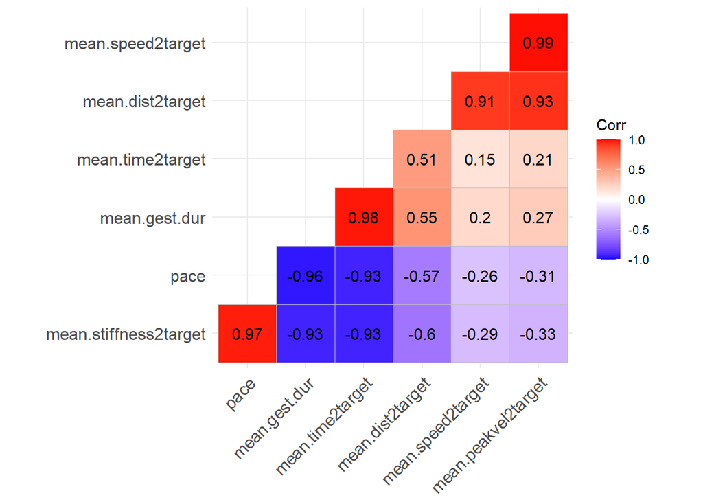

```r
dfcor <- df %>% select(mean.speed2target, mean.gest.dur, mean.time2target ,mean.peakvel2target,  mean.dist2target, mean.stiffness2target, pace)
r <- cor(dfcor, use="complete.obs")

ggcorrplot(r,
           hc.order = TRUE,
           type = "lower",
           lab = TRUE)
```

Some plots:

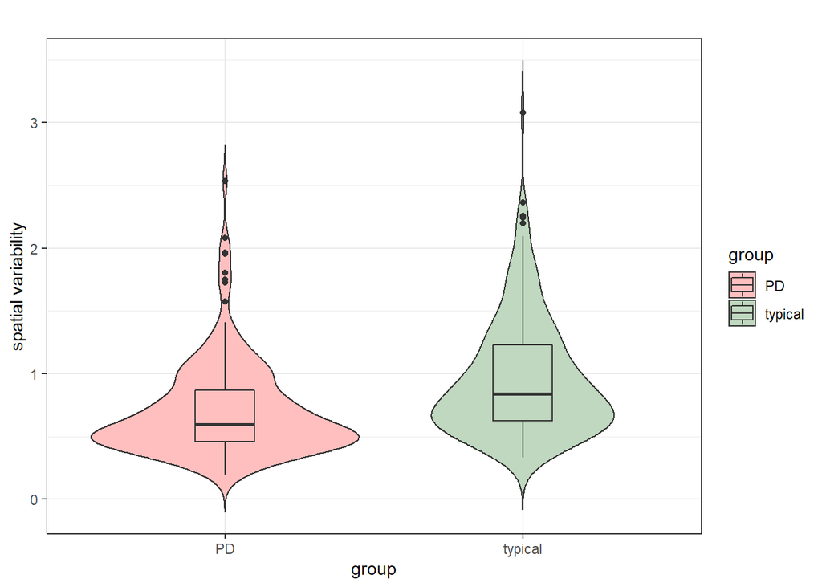

```r
dodge = .5
dodge <- position_dodge(width = 0.9)

ggplot(df, aes(x=group, y=spat_var_bivariate, fill=group)) + geom_violin(trim=FALSE) + labs(title = "", y = "spatial variability") + geom_boxplot(width=.2, position = dodge) + scale_fill_manual(values=c("#ffbfbf", "#bfd8bf")) + theme_bw()
```

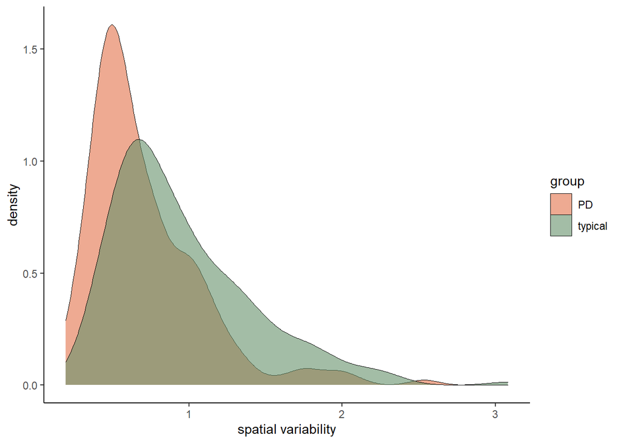

```r
ggplot(df, aes(x=spat_var_bivariate, fill = group)) +
  geom_density(size = 0, alpha=0.6) + theme_classic() +labs(x="spatial variability") + scale_fill_manual(values=c("#e37249", "#66916a"))
```

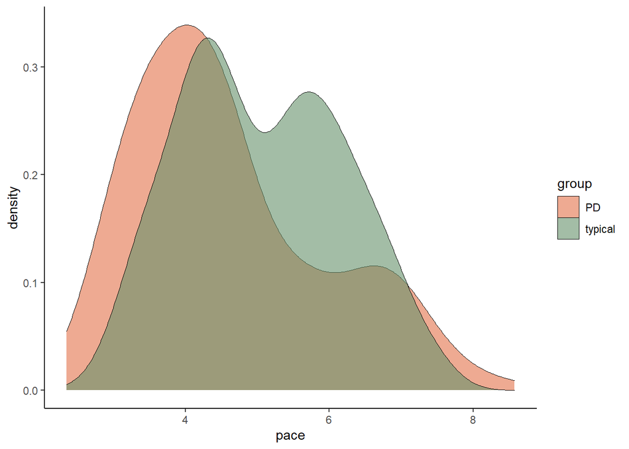

```r
ggplot(df, aes(x=pace, fill = group)) +
  geom_density(size = 0, alpha=0.6) + theme_classic() + labs(x="pace") + scale_fill_manual(values=c("#e37249", "#66916a"))
```

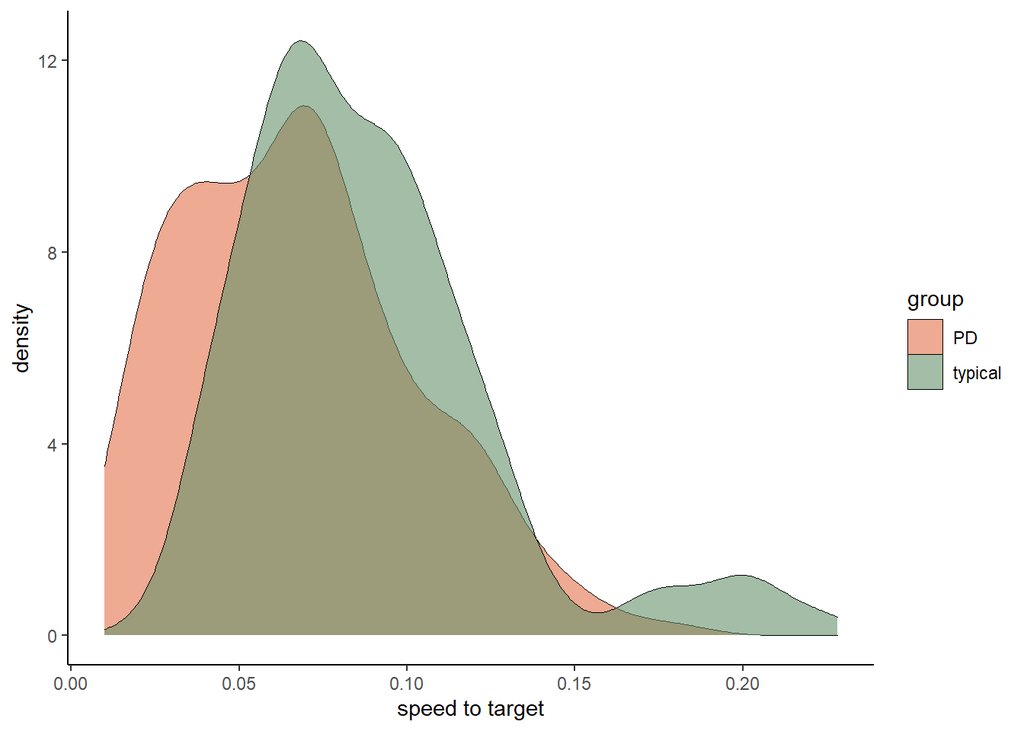

```r
ggplot(df, aes(x=mean.speed2target, fill = group)) +
  geom_density(size = 0, alpha=0.6) +labs(x="speed to target") + theme_classic() + scale_fill_manual(values=c("#e37249", "#66916a"))
```

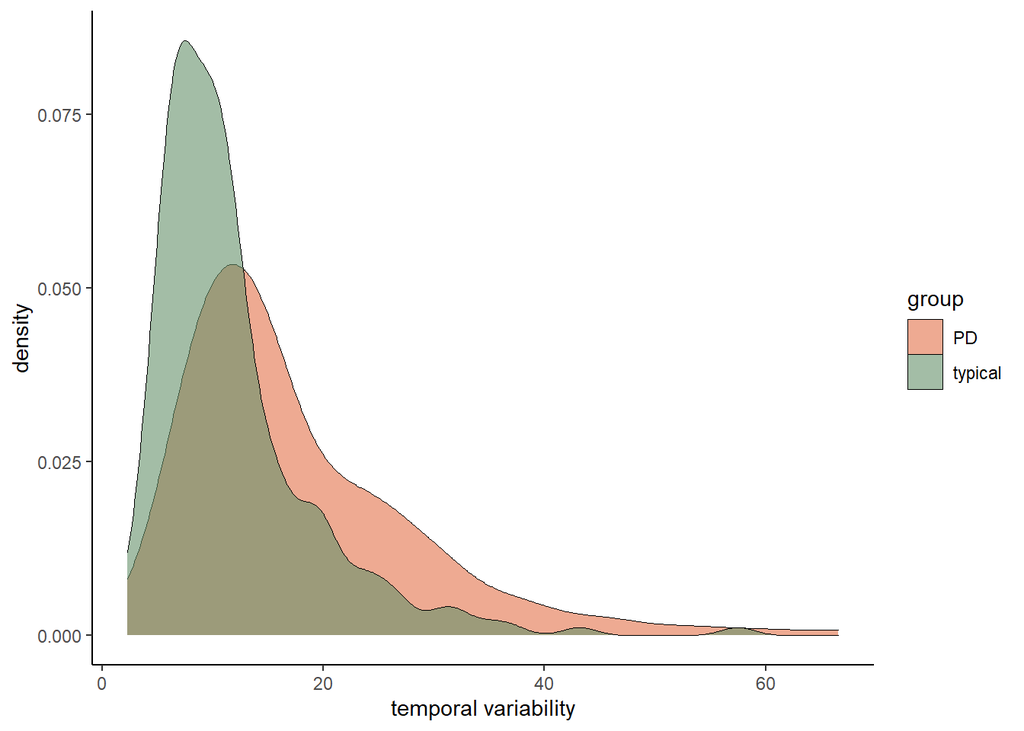

```r
ggplot(df, aes(x=temp_var, fill = group)) +
  geom_density(size = 0, alpha=0.6) + theme_classic() +labs(x="temporal variability") + scale_fill_manual(values=c("#e37249", "#66916a"))
```

# 5 Hypothesis testing

First model

```r
summary(m0 <- bam(spat_var_bivariate ~ s(subj,bs='re'), data = df, method = "ML"))
```

```
##
## Family: gaussian
## Link function: identity
##
## Formula:
## spat_var_bivariate ~ s(subj, bs = "re")
##
## Parametric coefficients:
##             Estimate Std. Error t value Pr(>|t|)
## (Intercept)   0.8556     0.0376   22.76   <2e-16 ***
## ---
## Signif. codes:  0 '***' 0.001 '**' 0.01 '*' 0.05 '.' 0.1 ' ' 1
##
## Approximate significance of smooth terms:
##           edf Ref.df     F p-value
## s(subj) 28.21     41 2.449  <2e-16 ***
## ---
## Signif. codes:  0 '***' 0.001 '**' 0.01 '*' 0.05 '.' 0.1 ' ' 1
##
## R-sq.(adj) =  0.203   Deviance explained =   26%
## -ML = 221.28  Scale est. = 0.15716   n = 397
```

Add group?

```r
summary(m1 <- bam(spat_var_bivariate ~ groupO + s(subj,bs='re'), data = df, method = "ML"))
```

```
##
## Family: gaussian
## Link function: identity
##
## Formula:
## spat_var_bivariate ~ groupO + s(subj, bs = "re")
##
## Parametric coefficients:
##               Estimate Std. Error t value Pr(>|t|)
## (Intercept)    0.72195    0.04715  15.313  < 2e-16 ***
## groupOtypical  0.24066    0.06371   3.778 0.000184 ***
## ---
## Signif. codes:  0 '***' 0.001 '**' 0.01 '*' 0.05 '.' 0.1 ' ' 1
##
## Approximate significance of smooth terms:
##           edf Ref.df     F  p-value
## s(subj) 22.86     40 1.463 3.78e-06 ***
## ---
## Signif. codes:  0 '***' 0.001 '**' 0.01 '*' 0.05 '.' 0.1 ' ' 1
##
## R-sq.(adj) =  0.197   Deviance explained = 24.6%
## -ML = 215.41  Scale est. = 0.15833   n = 397
```

```r
compareML(m0, m1)
```

```
## m0: spat_var_bivariate ~ s(subj, bs = "re")
##
## m1: spat_var_bivariate ~ groupO + s(subj, bs = "re")
##
## Chi-square test of ML scores
## -----
##   Model    Score Edf Difference    Df   p.value Sig.
## 1    m0 221.2782   2
## 2    m1 215.4137   3      5.865 1.000 6.153e-04  ***
##
## AIC difference: 0.32, model m1 has lower AIC.
```

Yes, typical speakers are more variable in comparison to PD speakers.

Final model:

```r
summary(mFinalHypothesis <- bam(spat_var_bivariate ~ groupO + s(subj,bs='re'), data = df))
```

```
##
## Family: gaussian
## Link function: identity
##
## Formula:
## spat_var_bivariate ~ groupO + s(subj, bs = "re")
##
## Parametric coefficients:
##               Estimate Std. Error t value Pr(>|t|)
## (Intercept)    0.72274    0.04839  14.937  < 2e-16 ***
## groupOtypical  0.23991    0.06541   3.668  0.00028 ***
## ---
## Signif. codes:  0 '***' 0.001 '**' 0.01 '*' 0.05 '.' 0.1 ' ' 1
##
## Approximate significance of smooth terms:
##          edf Ref.df     F  p-value
## s(subj) 23.7     40 1.521 3.48e-06 ***
## ---
## Signif. codes:  0 '***' 0.001 '**' 0.01 '*' 0.05 '.' 0.1 ' ' 1
##
## R-sq.(adj) =    0.2   Deviance explained = 24.9%
## fREML = 219.76  Scale est. = 0.15791   n = 397
```